# SeuratVizHelper Example: Stacked Violin Plot

SeuratVizHelper

2026-01-05

## はじめに

このドキュメントでは、SeuratVizHelperパッケージの`StackVln`関数を使用して、 Scanpy風のスタックバイオリンプロットを作成する方法を示します。

## 必要なライブラリの読み込み

# install.packages(“devtools”)

# devtools::install_github(“AyumuOkumura/SeuratVizHelper”)

```r
# 必要なパッケージを読み込み
library(Seurat)
library(SeuratVizHelper)

# データセットのダウンロードに必要なパッケージ
if (!requireNamespace("SeuratData", quietly = TRUE)) {
  if (!requireNamespace("remotes", quietly = TRUE)) {
    install.packages("remotes")
  }
  remotes::install_github('satijalab/seurat-data')
}
library(SeuratData)
```

## データセットのダウンロードと読み込み

`pbmc3k`データセットをSeuratDataパッケージからダウンロードして読み込みます。 このデータセットは、PBMCのデモンストレーションに適したサイズです。

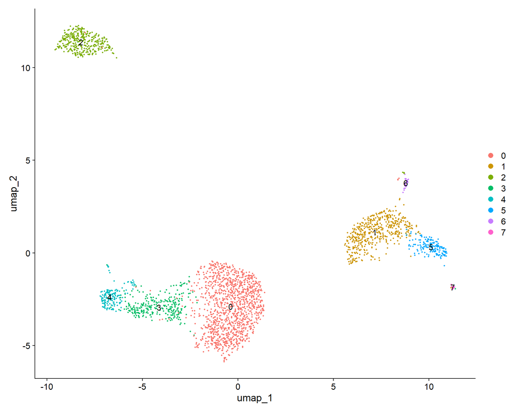

```r
SeuratData::InstallData("pbmc3k")
pbmc <- SeuratData::LoadData("pbmc3k")

ndim <- 30
pbmc <- pbmc %>%
  NormalizeData() %>%
  FindVariableFeatures() %>%
  ScaleData() %>%
  RunPCA(verbose = FALSE) %>%
  FindNeighbors(dims = 1:ndim, verbose = FALSE) %>%
  FindClusters(resolution = 0.6, verbose = FALSE) %>%
  RunUMAP(dims = 1:ndim, n.neighbors = 30, verbose = FALSE)

# 結果確認
DimPlot(pbmc, reduction = "umap", label = TRUE)
```

## マーカー遺伝子の指定

以下のマーカー遺伝子を使用してStackVlnプロットを作成します：

```r
# マーカー遺伝子のリスト
markers <- c('C1QA', 'PSAP', 'CD79A', 'CD79B', 'CST3', 'LYZ')

# データセットに存在する遺伝子のみを使用
available_markers <- markers[markers %in% rownames(pbmc)]

if (length(available_markers) == 0) {
  # 指定されたマーカーが存在しない場合、代替の遺伝子を使用
  cat("指定されたマーカー遺伝子がデータセットに含まれていません。\n")
  cat("代替の遺伝子を使用します。\n")
  # データセットに存在する遺伝子から選択
  available_markers <- head(VariableFeatures(pbmc), 6)
}

cat("使用するマーカー遺伝子:\n")
```

```
## 使用するマーカー遺伝子:
```

```r
print(available_markers)
```

```
## [1] "C1QA"  "PSAP"  "CD79A" "CD79B" "CST3"  "LYZ"
```

## StackVlnプロットの作成

`StackVln`関数を使用して、Scanpy風のスタックバイオリンプロットを作成します。

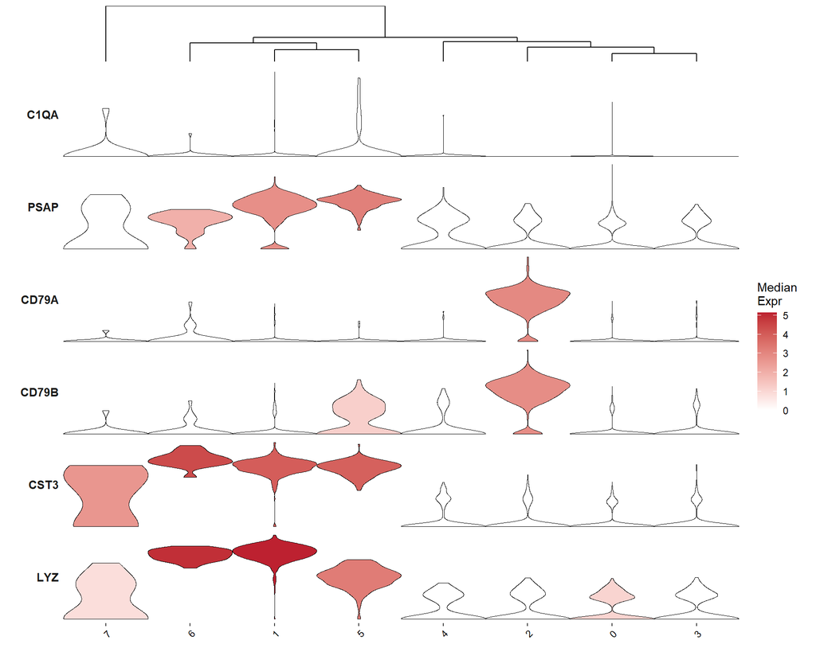

```r
# StackVlnプロットの作成
StackVln_p <- StackVln(
  seurat_object = pbmc,
  features      = available_markers,
  group.by      = "seurat_clusters",
  dendrogram_method = "dims",
  ndim = 30,
  plot_width    = 5,
  plot_heights  = c(0.3, 3), # 「上のグラフ（デンドログラム）」と「下のグラフ（バイオリンプロット）」の高さの比率を定義
  save_dir      = file.path("png/ViolinPlot")
)

StackVln_p
```

## カスタマイズされたプロット

色をカスタマイズした例：

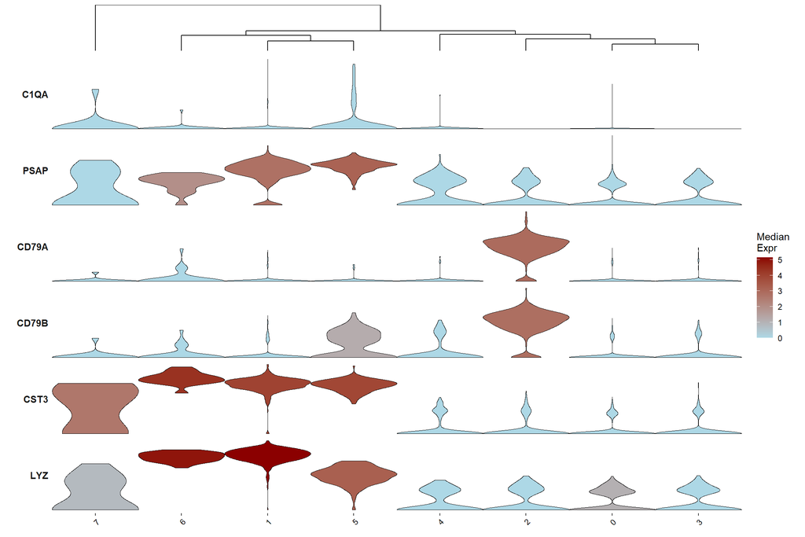

```r
# カスタムカラーでプロット
StackVln_p <- StackVln(
  seurat_object = pbmc,
  features      = available_markers,
  group.by      = "seurat_clusters",
  dendrogram_method = "dims",
  ndim = 30,
  plot_width    = 5,
  plot_heights  = c(0.3, 3), # 「上のグラフ（デンドログラム）」と「下のグラフ（バイオリンプロット）」の高さの比率を定義
    color_low = "lightblue",
  color_high = "darkred",
  save_dir      = file.path("png/ViolinPlot")
)
StackVln_p
```

## プロットの保存

プロットをファイルに保存する例（`plot_width`パラメータはファイル保存時に適用されます）：

```r
# プロットをファイルに保存
StackVln_p <- StackVln(
  seurat_object = pbmc,
  features = available_markers,
  color_high = "#BD2130",
  plot_width = 12,
  save_dir = "./figures"
)
StackVln_p
```

[output not shown]

## まとめ

このドキュメントでは、SeuratVizHelperパッケージを使用して：

1. PBMCデータセットを読み込み
2. マーカー遺伝子を指定
3. StackVlnプロットを作成

する方法を示しました。詳細なドキュメントは[GitHubリポジトリ](https://github.com/AyumuOkumura/SeuratVizHelper)をご覧ください。